# Assignment 1: Data set selection and initial Processing.

Jiaming Weng

## Introduction

### Overview

- Aged hematopoietic stem cells (HSC) display functional decline and associated with an increased risk of myeloid malignancies. Studies in Aged murine HSCs suggesting that epigenetic shifts with age may contribute to HSC loss of function (Beerman et al. 2013), and human histone modification levels has been profiled (Cheung et al. 2018), but detailed human studies of aged human HSCs are still lacking. To investigate the genomic mechanism of the epigenetic differences we observed in aged HSCe, we performed an analysis of RNA-sequencing (RNA-seq) profiles of young and aged Lineage−CD34+CD38− cells [HSC-enriched (HSCe)] .

### Data and Experimental Conditions

- We have selected the GEO dataset with the accession number GSE104406 for further analysis. The original publication is [Aging Human Hematopoietic Stem Cells Manifest Profound Epigenetic Reprogramming of Enhancers That May Predispose to Leukemia (RNA-Seq of HSCe)](https://doi.org/10.1158/2159-8290.CD-18-1474) (Adelman et al. 2019)
- It contains RNA-seq data from human bone marrow-derived hematopoietic stem cells (HSCs) from young (18-30 years old) and aged (65-75 years old) donors with no known hematological malignancy. We used the 10 biological replicates from the young donors as our control group and the 10 biological replicates from the aged donors as the experimental group.

## Data Selection and Cleaning

- We import the packages required for our analysis.

### Dependencies

```r
if (! requireNamespace("BiocManager", quietly = TRUE)) {
  install.packages("BiocManager")
}

if (! requireNamespace("limma", quietly = TRUE)) {
  BiocManager::install("limma")
}

if (! requireNamespace("GEOquery", quietly = TRUE)) {
  BiocManager::install("GEOquery")
}

if (! requireNamespace("knitr", quietly = TRUE)) {
  install.packages("knitr")
}

if (! requireNamespace("dplyr", quietly = TRUE)) {
  install.packages("dplyr")
}

if (! requireNamespace("edgeR", quietly = TRUE)) {
  BiocManager::install("edgeR")
}

if (! requireNamespace("biomaRt", quietly = TRUE)) {
  BiocManager::install("biomaRt")
}

library(Biobase)
library(GEOquery)
library(limma)
library(knitr)
library(edgeR)
library(biomaRt)
library(dplyr)
```

### Data Exploration

- We use the GEOquery Bioconductor package to retrieve the metadata and information.

```r
gse <- getGEO("GSE104406",GSEMatrix=FALSE)
current_gpl <- names(GPLList(gse))[1]
current_gpl_info <- Meta(getGEO(current_gpl))
```

- **Platform title** : Illumina HiSeq 2500 (Homo sapiens)
- **Submission data** : Mar 14 2013
- **Last update data** : Mar 27 2019
- **Organism** : Homo sapiens
- **Number of GEO datasets that use this technology**: 10510
- **Number of GEO samples that use this technology**: 300560
- We then procure the raw counts in the supplementary files and map the filenames to the sample.

```r
sfiles <- getGEOSuppFiles("GSE104406")
fnames <- rownames(sfiles)

gset <- getGEO("GSE104406",GSEMatrix=T)
sample_info <- pData(gset[[1]])

untar(fnames[2], exdir = "./GSE104406")
raw_fnames <- untar(fnames[2],list=TRUE)

# get the working directory for sorting data
wd <- paste0(getwd(),"/GSE104406/")
```

### Data Preperation

- We merge all raw count txt files into one dataframe to facilitate our future analysis.

```r
col_names <- c("Ensembl_ID")
gender <- c()
for (i in seq_along(raw_fnames)){
  # convert GSM to sample name
  col_names[i+1] <- gsub("_RNA", "",
                         sample_info[unlist(strsplit(raw_fnames[i], split = "\\_"))[1],1])
  gender[i] <-
    sample_info[unlist(strsplit(raw_fnames[i], split = "\\_"))[1],ncol(sample_info)]

  curr <- read.table(gzfile(paste0(wd, raw_fnames[i])),header=F)
  if (i == 1){
    raw_dat <- curr
  }
  else{
    raw_dat <- cbind(raw_dat, curr[,2])
  }
}
colnames(raw_dat) <- col_names
dim(raw_dat)
```

```
## [1] 57260    21
```

```r
samples <- data.frame(lapply(colnames(raw_dat)[2:21],
        FUN=function(x){unlist(strsplit(x,
                        split = "\\_"))[c(1,2)]}))
colnames(samples) <- colnames(raw_dat)[2:21]
rownames(samples) <- c("age_group","patient")
samples <- data.frame(t(samples))
# add a factor gender
samples <- cbind(samples, gender = gender)

knitr::kable(head(samples), format = "html")
```

|  | age_group | patient | gender |
| --- | --- | --- | --- |
| Young_1 | Young | 1 | M |
| Young_12 | Young | 12 | M |
| Young_16 | Young | 16 | F |
| Young_17 | Young | 17 | M |
| Young_25 | Young | 25 | M |
| Young_4 | Young | 4 | F |

### Quality Control

- First, we check the quality of our data, remove repetitive rows or unexpected values like NAs.

```r
# Check repititions
summarized_gene_counts <- sort(table(raw_dat$Ensembl_ID),
                               decreasing = TRUE)
kable(summarized_gene_counts[1:3], format="html")
```

| Var1 | Freq |
| --- | --- |
| alignment_not_unique | 1 |
| ambiguous | 1 |
| ENSG00000000003.10 | 1 |

```r
# Check NA
kable(tail(raw_dat), format="html")
```

|  | Ensembl_ID | Young_1 | Young_12 | Young_16 | Young_17 | Young_25 | Young_4 | Young_5 | Young_6 | Young_7 | Young_9 | Old_11 | Old_18 | Old_19 | Old_21 | Old_22 | Old_23 | Old_25 | Old_28 | Old_20 | Old_4 |
| --- | --- | --- | --- | --- | --- | --- | --- | --- | --- | --- | --- | --- | --- | --- | --- | --- | --- | --- | --- | --- | --- |
| 57255 | ENSGR0000270726.1 | 0 | 0 | 0 | 0 | 0 | 0 | 0 | 0 | 0 | 0 | 0 | 0 | 0 | 0 | 0 | 0 | 0 | 0 | 0 | 0 |
| 57256 | no_feature | 17556244 | 16886342 | 17381271 | 33127149 | 16541484 | 30843553 | 27064053 | 15490091 | 40533188 | 54587879 | 15452709 | 34946171 | 18203498 | 16018507 | 26240062 | 17324530 | 21743822 | 17756977 | 16009428 | 24399070 |
| 57257 | ambiguous | 614608 | 630621 | 544154 | 1240579 | 601583 | 882772 | 1043181 | 742709 | 1296841 | 1633528 | 753445 | 1295465 | 901200 | 502992 | 671673 | 772843 | 1114093 | 722795 | 560992 | 1158365 |
| 57258 | too_low_aQual | NA | NA | NA | NA | NA | NA | NA | NA | NA | NA | NA | NA | NA | NA | NA | NA | NA | NA | NA | NA |
| 57259 | not_aligned | 0 | 0 | 0 | 0 | 0 | 0 | 0 | 0 | 0 | 0 | 0 | 0 | 0 | 0 | 0 | 0 | 0 | 0 | 0 | 0 |
| 57260 | alignment_not_unique | 11241261 | 11852607 | 10473652 | 20524563 | 10989956 | 15896198 | 10667596 | 20280450 | 23732087 | 25881293 | 5632744 | 25375196 | 9508190 | 10415244 | 15104690 | 9254751 | 35510695 | 8114389 | 9618097 | 15712802 |

```r
# removed, because it impaired cpm
raw_dat <- raw_dat[-57256: -57260, ]
kable(tail(raw_dat), format="html")
```

|  | Ensembl_ID | Young_1 | Young_12 | Young_16 | Young_17 | Young_25 | Young_4 | Young_5 | Young_6 | Young_7 | Young_9 | Old_11 | Old_18 | Old_19 | Old_21 | Old_22 | Old_23 | Old_25 | Old_28 | Old_20 | Old_4 |
| --- | --- | --- | --- | --- | --- | --- | --- | --- | --- | --- | --- | --- | --- | --- | --- | --- | --- | --- | --- | --- | --- |
| 57250 | ENSGR0000264510.1 | 0 | 0 | 0 | 0 | 0 | 0 | 0 | 0 | 0 | 0 | 0 | 0 | 0 | 0 | 0 | 0 | 0 | 0 | 0 | 0 |
| 57251 | ENSGR0000264819.1 | 0 | 0 | 0 | 0 | 0 | 0 | 0 | 0 | 0 | 0 | 0 | 0 | 0 | 0 | 0 | 0 | 0 | 0 | 0 | 0 |
| 57252 | ENSGR0000265350.1 | 0 | 0 | 0 | 0 | 0 | 0 | 0 | 0 | 0 | 0 | 0 | 0 | 0 | 0 | 0 | 0 | 0 | 0 | 0 | 0 |
| 57253 | ENSGR0000265658.1 | 0 | 0 | 0 | 0 | 0 | 0 | 0 | 0 | 0 | 0 | 0 | 0 | 0 | 0 | 0 | 0 | 0 | 0 | 0 | 0 |
| 57254 | ENSGR0000266731.1 | 0 | 0 | 0 | 0 | 0 | 0 | 0 | 0 | 0 | 0 | 0 | 0 | 0 | 0 | 0 | 0 | 0 | 0 | 0 | 0 |
| 57255 | ENSGR0000270726.1 | 0 | 0 | 0 | 0 | 0 | 0 | 0 | 0 | 0 | 0 | 0 | 0 | 0 | 0 | 0 | 0 | 0 | 0 | 0 | 0 |

- Then, we filter out the weakly expressed genes according to edgeR
  - We only keep features with at least 1 count per million in 10 of our samples, as by our study design, each group has 10 replicates, any feature that didn’t satisfied this requirement can be noise instead of our desired biological difference.

```r
# translate out counts into counts per million using the edgeR package function cpm
cpms <- cpm(raw_dat[,2:21])
rownames(cpms) <- raw_dat[,1]

# filter low counts noise, comparing 10 samples to 10 samples
keep <- rowSums(cpms >1) >=10
HSCe_exp_filtered <- raw_dat[keep,]
dim(HSCe_exp_filtered)
```

```
## [1] 14383    21
```

```r
summarized_gene_counts_filtered <- sort(table(HSCe_exp_filtered$Ensembl_ID),
                               decreasing = TRUE)

nrow(HSCe_exp_filtered)/nrow(raw_dat)
```

```
## [1] 0.2512095
```

- We then further analyse the 0.251 of the genes.

## Normalization

### TMM

- We apply TMM(weighted trimmed mean of M-values) (Robinson, McCarthy, and Smyth 2010) in the edgeR package to our dataset as it is one of the most the recommended normalization methods for RNAseq data based on count values, based on the hypothesis that most genes are not differentially expressed and our data is roughly balanced. Moreover, the data does not need to be modified or trimmed prior to normalization.

```r
filtered_data_matrix <- as.matrix(HSCe_exp_filtered[,2:21])
rownames(filtered_data_matrix) <- HSCe_exp_filtered$Ensembl_ID
d <- DGEList(counts=filtered_data_matrix, group=samples$age_group)
d <- calcNormFactors(d)
```

### Pre- and Post- Normalization Comparison

- We will comparing the post-normalization data with the our clean, pre-normalized data .

```r
# Pre-normalization
pre_counts <- cpm(HSCe_exp_filtered[,2:21])

# After-normalization
normalized_counts <- cpm(d)
rownames(normalized_counts) <- rownames(filtered_data_matrix)
```

**1. Distribution: Boxplot Plot**

```r
boxplot_cpm <- function(cpm_dat, color ="pink", cap){
  data2plot <- log2(cpm_dat)
  boxplot(data2plot, xlab = "Samples", ylab = "log2 CPM",
          las = 2, cex = 0.5, cex.lab = 0.5,
          cex.axis = 0.5, main = paste0("Boxplot: HSCe RNASeq Samples - ",cap))
  #draw the median on each box plot
  abline(h = median(apply(data2plot, 2, median)),
         col = color, lwd = 2, lty = "dashed")
}
```

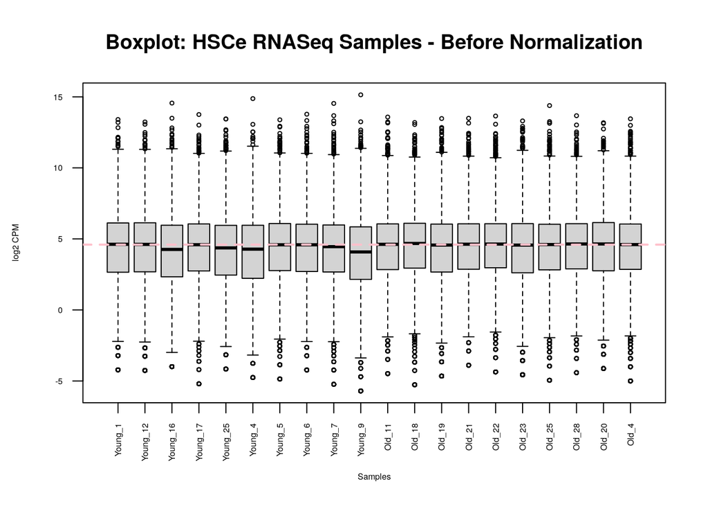

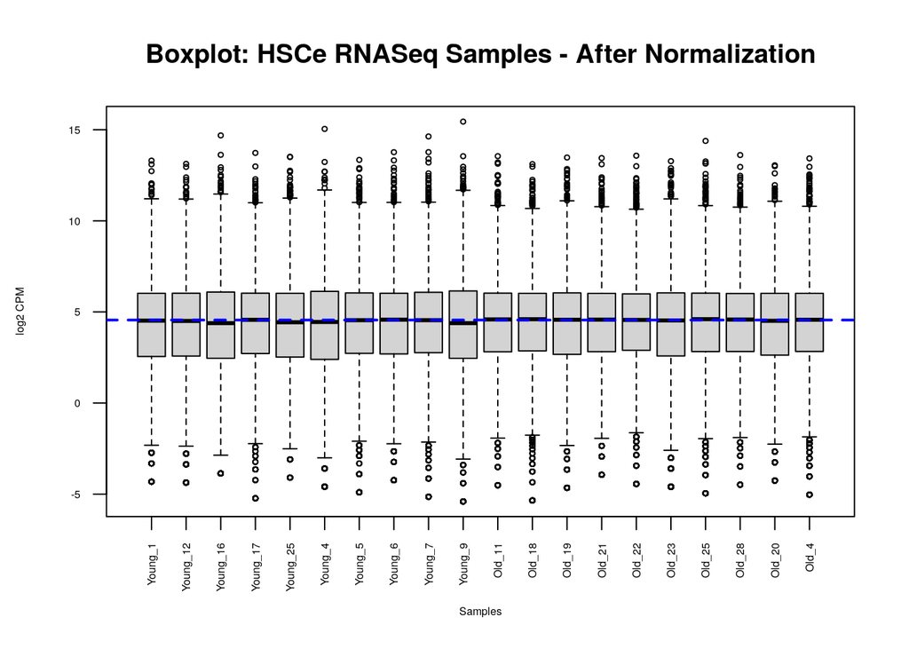

```r
boxplot_cpm(pre_counts, "pink", "Before Normalization")
boxplot_cpm(normalized_counts, "blue", "After Normalization")
```

- The boxplots indicate that the overall pattern of distribution is similar across the samples.

- We have illustrated that through our normalization, we reduce the differences between the quantiles of each sample, and the normalized medians are more consistent.

**2. Distribution: Density Plot**

```r
plot_density <- function(cpm_dat, cap){
  counts_density <- apply(log2(cpm_dat),
                          2, density)
  data2plot <- log2(cpm_dat)
  #calculate the limits across all the samples
  xlim <- 0; ylim <- 0
  for (i in 1:length(counts_density)) {
    xlim <- range(c(xlim, counts_density[[i]]$x));
    ylim <- range(c(ylim, counts_density[[i]]$y))
  }
  cols <- rainbow(length(counts_density))
  ltys <- rep(1, length(counts_density))
  #plot the first density plot to initialize the plot
  plot(counts_density[[1]], xlim=xlim, ylim=ylim, type="n",
       ylab="Smoothing density of log2-CPM",
       main= paste0("Density: HSCe RNASeq Samples - ",cap), cex.lab = 0.85)
  #plot each line
  for (i in 1:length(counts_density))
    lines(counts_density[[i]], col=cols[i], lty=ltys[i])
  #create legend
  legend("topright", colnames(data2plot),
         col=cols, lty=ltys, cex=0.75,
         border ="blue",  text.col = "green4",
         merge = TRUE, bg = "gray90")
}
```

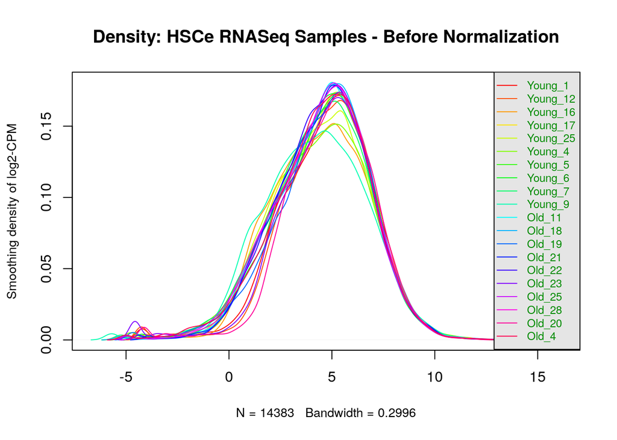

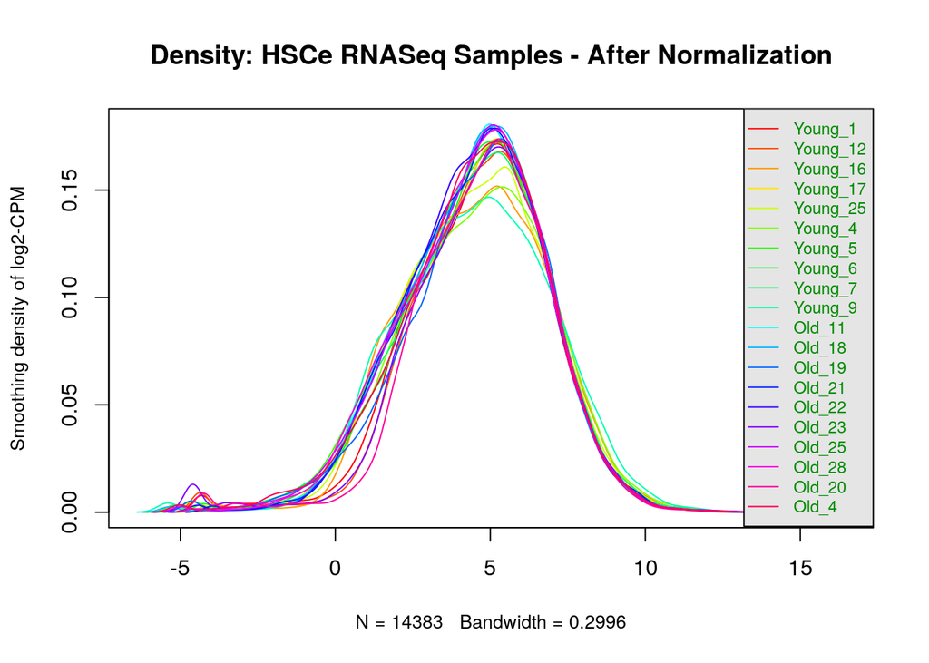

```r
plot_density(pre_counts, "Before Normalization")
plot_density(normalized_counts, "After Normalization")
```

- Both density plots share a similar scale, and our pre- and after-normalized data show a similar distribution.
- We have illustrated that after the normalization, the samples have less dispersed distributions, with less extremes and data is more concentrated in the center.

From the distribution above, we show that have successfully minimized the technical variation between samples, and we are more confident that the abundance of given genes will vary because of biological variation (age).

**3. MDS Plot**

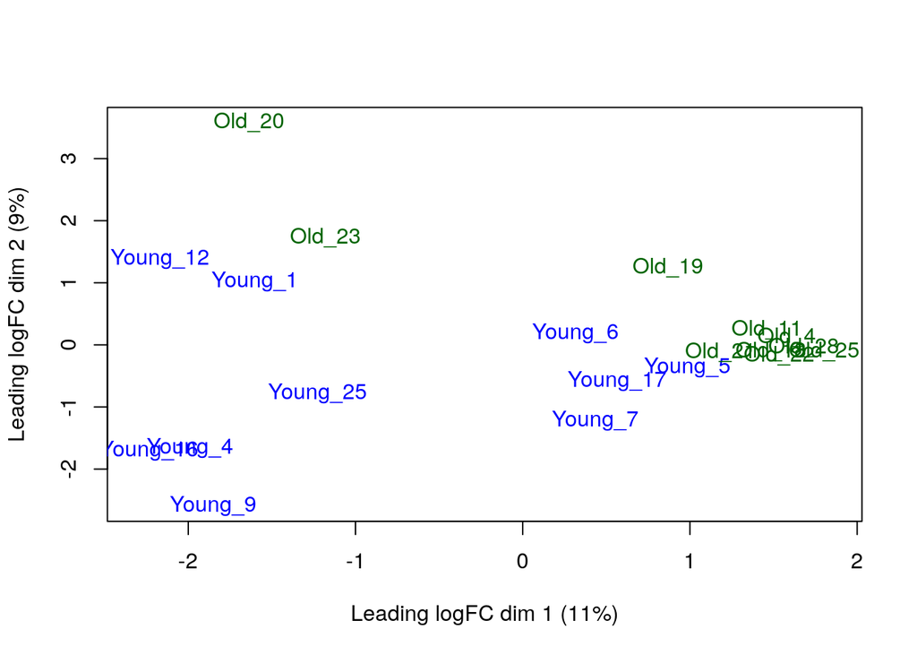

```r
plotMDS(d, labels=rownames(samples),
  col = c("darkgreen","blue")[factor(samples$age_group)])
```

- Interestingly, we found 3 outliers of the old group, and their genders are all women. We should be careful of the potential batch effect of gender in our future expression analysis.

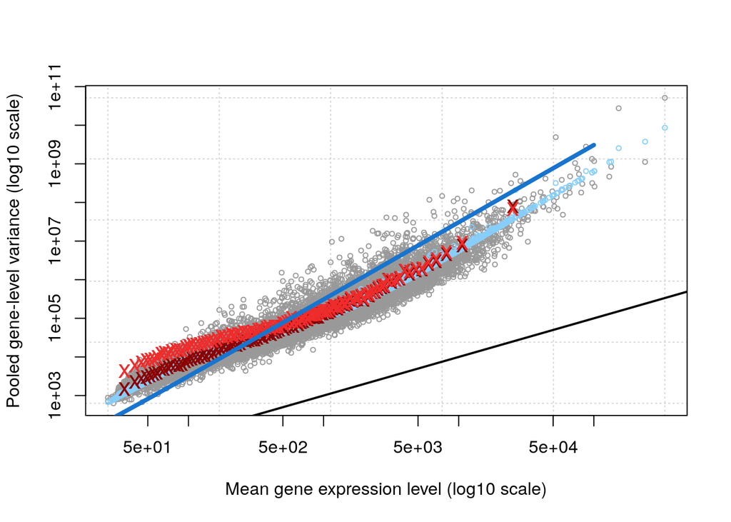

```r
# Calculate dispersion
model_design <- model.matrix(~samples$patient
                             + samples$age_group+0)
d <- estimateDisp(d, model_design)

#plot
plotMeanVar(d, show.raw.vars = TRUE, show.tagwise.vars=TRUE,
            show.ave.raw.vars = TRUE,
            NBline=TRUE,
            show.binned.common.disp.vars = TRUE)
```

## Identifier mapping

- We will convert the emsembl ids to the hgnc gene names

```r
# Connect to emsembl and get human dataset
ensembl <- useMart("ensembl")
ensembl <- useDataset("hsapiens_gene_ensembl",mart=ensembl)

# ENSG to HGNC, save
conversion_stash <- "HSCe_id_conversion.rds"
if(file.exists(conversion_stash)){
  HSCe_id_conversion <- readRDS(conversion_stash)
} else {
  HSCe_id_conversion <- getBM(attributes = c("ensembl_gene_id","hgnc_symbol"),
                            filters = c("ensembl_gene_id"),
                            # remove the points
                            values = gsub("\\..*", "", HSCe_exp_filtered$Ensembl_ID),
                            mart = ensembl)
  saveRDS(HSCe_id_conversion, conversion_stash)
}
```

- We calculate the coverage:

```r
mapped <- length(which(gsub("\\..*", "",rownames(normalized_counts)) %in%
                HSCe_id_conversion$ensembl_gene_id))
nrow(normalized_counts)-mapped
```

```
## [1] 430
```

```r
# merge
rownames(normalized_counts) <- gsub("\\..*", "",rownames(normalized_counts))
normalized_counts_annot <- merge(HSCe_id_conversion,normalized_counts,
                                 by.x = 1, by.y = 0, all.y=TRUE)
# rownames(normalized_counts_annot) <-  normalized_counts_annot$ensembl_gene_id
kable(normalized_counts_annot[1:5,],type = "html")
```

| ensembl_gene_id | hgnc_symbol | Young_1 | Young_12 | Young_16 | Young_17 | Young_25 | Young_4 | Young_5 | Young_6 | Young_7 | Young_9 | Old_11 | Old_18 | Old_19 | Old_21 | Old_22 | Old_23 | Old_25 | Old_28 | Old_20 | Old_4 |
| --- | --- | --- | --- | --- | --- | --- | --- | --- | --- | --- | --- | --- | --- | --- | --- | --- | --- | --- | --- | --- | --- |
| ENSG00000000003 | TSPAN6 | 13.05679 | 1.7478409 | 21.646904 | 12.814506 | 15.530876 | 12.30813 | 4.485413 | 0.000000 | 12.015937 | 5.974962 | 23.292639 | 5.453687 | 0.2785474 | 9.076326 | 2.767455 | 6.5384977 | 4.849304 | 9.910338 | 13.884790 | 11.288244 |
| ENSG00000000419 | DPM1 | 10.99784 | 13.9341762 | 28.931259 | 25.602371 | 16.527196 | 10.81623 | 13.322346 | 10.044500 | 15.161618 | 35.849772 | 21.976671 | 21.863882 | 27.2180566 | 14.169516 | 19.279940 | 15.7668838 | 9.860252 | 14.574026 | 5.344334 | 6.410986 |
| ENSG00000000457 | SCYL3 | 55.13985 | 33.3060797 | 11.132694 | 30.717517 | 16.937446 | 14.29732 | 32.669873 | 59.629254 | 30.096520 | 10.716995 | 53.033522 | 60.113392 | 67.0901220 | 40.157845 | 60.146031 | 52.2665990 | 37.630599 | 43.139118 | 27.612393 | 36.901515 |
| ENSG00000000460 | C1orf112 | 12.90614 | 0.0971023 | 7.971558 | 5.834463 | 20.395264 | 0.00000 | 15.933258 | 20.833037 | 21.623018 | 8.345979 | 9.869762 | 10.931941 | 2.5467187 | 12.014705 | 13.975650 | 25.1608014 | 5.237248 | 5.919297 | 15.142280 | 9.294396 |
| ENSG00000000938 | FGR | 0.00000 | 4.1753977 | 1.374407 | 2.051387 | 3.633639 | 0.00000 | 9.707237 | 4.357931 | 7.169887 | 15.340478 | 3.509249 | 1.424837 | 0.0000000 | 2.416000 | 1.798846 | 0.0413829 | 1.454791 | 2.331844 | 3.772471 | 3.619600 |

- Eventually, we have a final result of a dataframe with 22 columns (20 samples, 1 row for emsembl gene id, one column for HUGO symbols) with 13953 mapped genes as the rows.

Missing

```r
ensembl_id_missing_gene <- normalized_counts_annot$ensembl_gene_id[
  which(is.na(normalized_counts_annot$hgnc_symbol))]
num_missing <- length(ensembl_id_missing_gene)

# what are the missing values?
rownames(raw_dat) <- gsub("\\..*", "",raw_dat$Ensembl_ID)
old_mapping <- merge(raw_dat[,1],data.frame(ensembl_id_missing_gene), by.x = 1, by.y = 0, all.y=TRUE)
kable(old_mapping[1:10,], type="html")
```

| x | ensembl_id_missing_gene |
| --- | --- |
| 1 | ENSG00000005955 |
| 10 | ENSG00000108270 |
| 100 | ENSG00000184825 |
| 101 | ENSG00000184886 |
| 102 | ENSG00000185128 |
| 103 | ENSG00000185928 |
| 104 | ENSG00000186275 |
| 105 | ENSG00000186530 |
| 106 | ENSG00000187145 |
| 107 | ENSG00000187667 |

- There are some missing values that have a corresbonding HUGO symbol when querying manually, however, the emsembl db from biomaRT doesn’t have corresponding mapping.

## Interpret, and document

Adelman, Emmalee R., Hsuan-Ting Huang, Alejandro Roisman, André Olsson, Antonio Colaprico, Tingting Qin, R. Coleman Lindsley, et al. 2019. “Aging Human Hematopoietic Stem Cells Manifest Profound Epigenetic Reprogramming of Enhancers That May Predispose to Leukemia.” *Cancer Discovery* 9 (8): 1080–1101. https://doi.org/10.1158/2159-8290.CD-18-1474.

Beerman, Isabel, Christoph Bock, Brian S Garrison, Zachary D Smith, Hongcang Gu, Alexander Meissner, and Derrick J Rossi. 2013. “Proliferation-Dependent Alterations of the DNA Methylation Landscape Underlie Hematopoietic Stem Cell Aging.” *Cell Stem Cell* 12 (4): 413–25.

Cheung, Peggie, Francesco Vallania, Hayley C Warsinske, Michele Donato, Steven Schaffert, Sarah E Chang, Mai Dvorak, et al. 2018. “Single-Cell Chromatin Modification Profiling Reveals Increased Epigenetic Variations with Aging.” *Cell* 173 (6): 1385–97.

Robinson, Mark D, Davis J McCarthy, and Gordon K Smyth. 2010. “edgeR: A Bioconductor Package for Differential Expression Analysis of Digital Gene Expression Data.” *Bioinformatics* 26 (1): 139–40.